## Elements Of Data Science - S2022

# Week 3: Pandas, Data Exploration and Visualization

### 2/1/2022

# TODOs

- **Read** Selections from PDSH Chapter 3
- **Read** Selections from PDSH Chapter 4
- (Optional) Seaborn Tutorial https://seaborn.pydata.org/tutorial.html
- Complete Week 3 Quiz
- HW1 out this week, includes questions on Hypothesis Testing

# TODAY

- Pandas
- Data Exploration
- Visualization in Python

# Questions?

# Environment Setup

```python
import numpy as np
```

# Intro to Pandas

Pandas is an open source, BSD-licensed library providing:

- **high-performance, easy-to-use data structures** and
- **data analysis tools**

```python
# usually imported using the alias 'pd'
import pandas as pd
```

- Primary datastructures:
  - **Series**: 1D array with a flexible index
  - **Dataframe**: 2D matrix with flexible index and column names

# Pandas Series

- 1D array of data (any numpy datatype) plus an associated **index** array

```python
s = pd.Series(np.random.rand(4))
s
```

```
0    0.472418
1    0.924422
2    0.033124
3    0.441399
dtype: float64
```

```python
# return the values of the series
s.values
```

```
array([0.47241843, 0.9244225 , 0.03312375, 0.44139901])
```

```python
# return the index of the series
s.index
```

```
RangeIndex(start=0, stop=4, step=1)
```

# Pandas Series Cont.

- index is flexible, can be anything hashable (integers, strings, ...)

```python
# create Series from array and set index
s = pd.Series([1,2,3],index=['a','b','c'],name='Example_Series')
s
```

```
a    1
b    2
c    3
Name: Example_Series, dtype: int64
```

```python
s['a']
```

```
1
```

```python
s[['b','c']]
```

```
b    2
c    3
Name: Example_Series, dtype: int64
```

# Pandas Series Cont.

- accessing other Series attributes

```python
s
```

```
a    1
b    2
c    3
Name: Example_Series, dtype: int64
```

```python
print(f'{s.index  = :}')
print(f'{s.values = :}')
print(f'{s.name   = :>20s}')
print(f'{s.dtype  = :}')
print(f'{s.shape  = :}')
'{:>20s}'.format(s.name)
```

```
s.index  = Index(['a', 'b', 'c'], dtype='object')
s.values = [1 2 3]
s.name   =       Example_Series
s.dtype  = int64
s.shape  = (3,)
```

```
'      Example_Series'
```

# Pandas Series Cont.

```python
# Can create series with index from a dictionary
s = pd.Series({'a':1,'b':2,'c':3,'d':4})
s
```

```
a    1
b    2
c    3
d    4
dtype: int64
```

```python
print(f'{s.index  = :}')
print(f'{s.values = :}')
```

```
s.index  = Index(['a', 'b', 'c', 'd'], dtype='object')
s.values = [1 2 3 4]
```

# Pandas DataFrame

- tabular datastructure
- each column a single datatype
- contains both row and column indices
- single column == Series

# Pandas DataFrame Cont.

```python
df = pd.DataFrame({'Year':[2017,2018,2018,2019],
                   'Class_Name':['A','A','B','A'],
                   'Measure1':[2.1,3.0,2.4,1.9]
                  })
```

```python
df
```

|  | Year | Class_Name | Measure1 |
| --- | --- | --- | --- |
| 0 | 2017 | A | 2.1 |
| 1 | 2018 | A | 3.0 |
| 2 | 2018 | B | 2.4 |
| 3 | 2019 | A | 1.9 |

```python
print(df)
```

```
   Year Class_Name  Measure1
0  2017          A       2.1
1  2018          A       3.0
2  2018          B       2.4
3  2019          A       1.9
```

```python
display(df)
```

|  | Year | Class_Name | Measure1 |
| --- | --- | --- | --- |
| 0 | 2017 | A | 2.1 |
| 1 | 2018 | A | 3.0 |
| 2 | 2018 | B | 2.4 |
| 3 | 2019 | A | 1.9 |

# Pandas DataFrame Cont.

```python
data = [[2017,'A',2.1],
        [2018,'A',3.0],
        [2018,'B',2.4],
        [2019,'A',1.9]]
```

```python
df = pd.DataFrame(data,
                  columns=['Year','Class_Name','Measure1'],
                  index=['001','002','003','004'])
df.shape
```

```
(4, 3)
```

```python
df
```

|  | Year | Class_Name | Measure1 |
| --- | --- | --- | --- |
| 001 | 2017 | A | 2.1 |
| 002 | 2018 | A | 3.0 |
| 003 | 2018 | B | 2.4 |
| 004 | 2019 | A | 1.9 |

# Pandas Attributes

- Get shape of DataFrame : `shape`

```python
df.shape # rows, columns
```

```
(4, 3)
```

- Get index values : `index`

```python
df.index
```

```
Index(['001', '002', '003', '004'], dtype='object')
```

- Get column values : `columns`

```python
df.columns
```

```
Index(['Year', 'Class_Name', 'Measure1'], dtype='object')
```

# Pandas Indexing/Selection

Select by label:

- `.loc[]`

```python
df.loc['001']
```

```
Year          2017
Class_Name       A
Measure1       2.1
Name: 001, dtype: object
```

```python
df.loc['001','Measure1']
```

```
2.1
```

# Pandas Indexing/Selection Cont.

Select by position:

- `.iloc[]`

```python
df.iloc[0]
```

```
Year          2017
Class_Name       A
Measure1       2.1
Name: 001, dtype: object
```

```python
df.iloc[0,2]
```

```
2.1
```

# Pandas Indexing/Selection Cont.

Selecting multiple rows/columns: use list (fancy indexing)

```python
df.loc[['002','004']]
```

|  | Year | Class_Name | Measure1 |
| --- | --- | --- | --- |
| 002 | 2018 | A | 3.0 |
| 004 | 2019 | A | 1.9 |

```python
df.loc[['002','004'],['Year','Measure1']]
```

|  | Year | Measure1 |
| --- | --- | --- |
| 002 | 2018 | 3.0 |
| 004 | 2019 | 1.9 |

# Pandas Slicing

```python
# Get last two rows
df.iloc[-2:]
```

|  | Year | Class_Name | Measure1 |
| --- | --- | --- | --- |
| 003 | 2018 | B | 2.4 |
| 004 | 2019 | A | 1.9 |

```python
# Get first two rows and first two columns
df.iloc[:2,:2]
```

|  | Year | Class_Name |
| --- | --- | --- |
| 001 | 2017 | A |
| 002 | 2018 | A |

**NOTE:** `.iloc` is **exclusive** (start:end+1)

# Pandas Slicing Cont.

Can also slice using labels:

```python
df.loc['002':'004']
```

|  | Year | Class_Name | Measure1 |
| --- | --- | --- | --- |
| 002 | 2018 | A | 3.0 |
| 003 | 2018 | B | 2.4 |
| 004 | 2019 | A | 1.9 |

```python
df.loc['002':'004',:'Class_Name']
```

|  | Year | Class_Name |
| --- | --- | --- |
| 002 | 2018 | A |
| 003 | 2018 | B |
| 004 | 2019 | A |

**NOTE**: `.loc` is **inclusive**

# Pandas Slicing Cont.

How to indicate all rows or all columns? `:`

```python
df.loc[:,'Measure1']
```

```
001    2.1
002    3.0
003    2.4
004    1.9
Name: Measure1, dtype: float64
```

```python
df.iloc[2:,:]
```

|  | Year | Class_Name | Measure1 |
| --- | --- | --- | --- |
| 003 | 2018 | B | 2.4 |
| 004 | 2019 | A | 1.9 |

# Pandas Indexing Cont.

Shortcut for indexing:

```python
df['Class_Name']
```

```
001    A
002    A
003    B
004    A
Name: Class_Name, dtype: object
```

```python
# can use dot notation if there is no space in label
df.Class_Name
```

```
001    A
002    A
003    B
004    A
Name: Class_Name, dtype: object
```

# Panda Selection Chaining

Get 'Year' and 'Measure1' for first 3 rows:

```python
df.iloc[:3].loc[:,['Year','Measure1']]
```

|  | Year | Measure1 |
| --- | --- | --- |
| 001 | 2017 | 2.1 |
| 002 | 2018 | 3.0 |
| 003 | 2018 | 2.4 |

For records '001' and '003' get last two columns

```python
df.loc[['001','003']].iloc[:,-2:]
```

|  | Class_Name | Measure1 |
| --- | --- | --- |
| 001 | A | 2.1 |
| 003 | B | 2.4 |

# Panda Selection Chaining Cont.

For record '001' get last two columns?:

```python
# reduce the amount of error information printed
%xmode Minimal
```

```
Exception reporting mode: Minimal
```

```python
# Note: add 'raises-exception' tag to cell to continue running after exception

df.loc['001'].iloc[:,-2:] # row with label '001', then all rows, last two columns?
```

```
IndexingError: Too many indexers
```

```python
df.loc['001']
```

```
Year          2017
Class_Name       A
Measure1       2.1
Name: 001, dtype: object
```

```python
df.loc['001'].iloc[-2:] # row with label '001', last two elements of Series
```

```
Class_Name      A
Measure1      2.1
Name: 001, dtype: object
```

# Pandas `head` and `tail`

Get a quick view of the first or last rows in a DataFrame

```python
df.head() # first 5 rows by default
```

|  | Year | Class_Name | Measure1 |
| --- | --- | --- | --- |
| 001 | 2017 | A | 2.1 |
| 002 | 2018 | A | 3.0 |
| 003 | 2018 | B | 2.4 |
| 004 | 2019 | A | 1.9 |

```python
df.tail(2) # only print last 2 rows
```

|  | Year | Class_Name | Measure1 |
| --- | --- | --- | --- |
| 003 | 2018 | B | 2.4 |
| 004 | 2019 | A | 1.9 |

# Pandas Boolean Mask

```python
# Which rows have Class_Name of 'A'?
df.loc[:,'Class_Name'] == 'A'
```

```
001     True
002     True
003    False
004     True
Name: Class_Name, dtype: bool
```

```python
# Get all data for rows with with Class_Name 'A'
df.loc[df.Class_Name == 'A']
```

|  | Year | Class_Name | Measure1 |
| --- | --- | --- | --- |
| 001 | 2017 | A | 2.1 |
| 002 | 2018 | A | 3.0 |
| 004 | 2019 | A | 1.9 |

```python
# Get Measure1 for all records for Class_Name 'A'
df.loc[df.Class_Name == 'A','Measure1']
```

```
001    2.1
002    3.0
004    1.9
Name: Measure1, dtype: float64
```

# Pandas Boolean Mask Cont.

Get all records for class 'A' before 2019

```python
df.loc[(df.Class_Name == 'A') & (df.Year < 2019)]
```

|  | Year | Class_Name | Measure1 |
| --- | --- | --- | --- |
| 001 | 2017 | A | 2.1 |
| 002 | 2018 | A | 3.0 |

Get all records in a set of years:

```python
df.loc[df.Year.isin([2017,2019])]
```

|  | Year | Class_Name | Measure1 |
| --- | --- | --- | --- |
| 001 | 2017 | A | 2.1 |
| 004 | 2019 | A | 1.9 |

# Pandas Selection Review

- `.loc[]`
- `.iloc[]`
- Fancy Indexing
- Slicing
- Chaining
- `head` and `tail`
- Boolean Mask

# Pandas Sorting

```python
df.sort_values(by=['Measure1']).head(3)
```

|  | Year | Class_Name | Measure1 |
| --- | --- | --- | --- |
| 004 | 2019 | A | 1.9 |
| 001 | 2017 | A | 2.1 |
| 003 | 2018 | B | 2.4 |

```python
df.sort_values(by=['Measure1'],ascending=False).head(3)
```

|  | Year | Class_Name | Measure1 |
| --- | --- | --- | --- |
| 002 | 2018 | A | 3.0 |
| 003 | 2018 | B | 2.4 |
| 001 | 2017 | A | 2.1 |

```python
df.sort_values(by=['Year','Measure1']).head(3)
```

|  | Year | Class_Name | Measure1 |
| --- | --- | --- | --- |
| 001 | 2017 | A | 2.1 |
| 003 | 2018 | B | 2.4 |
| 002 | 2018 | A | 3.0 |

# Questions?

# Exploratory Data Analysis

## For a new set of data, would like to know:

- amount of data (rows, columns)
- range (min, max)
- counts of discrete values
- central tendencies (mean, median)
- dispersion or spread (variance, IQR)
- skew
- covariance and correlation ...

# Yellowcab Dataset

- Records of Yellowcab Taxi trips from January 2017
- more info: https://www1.nyc.gov/site/tlc/about/tlc-trip-record-data.page

# Loading Datasets from CSV (Comma Separated Values)

- columns separated by delimiter, eg. comma, tab (\t), pipe (|)
- one row per record, observation
- often, strings quoted
- often, first row contains column headings
- often, comment rows starting with #

```python
!head ../data/yellowcab_demo_withdaycategories.csv
```

```
# A sample of yellocab taxi trip data from Jan 2017
pickup_datetime,dropoff_datetime,trip_distance,fare_amount,tip_amount,payment_type,day_of_week,is_weekend
2017-01-05 14:49:04,2017-01-05 14:53:53,0.89,5.5,1.26,Credit card,3,True
2017-01-15 01:07:22,2017-01-15 01:26:47,2.7,14.0,0.0,Cash,6,False
2017-01-29 09:55:00,2017-01-29 10:04:43,1.41,8.0,0.0,Cash,6,False
2017-01-10 05:40:12,2017-01-10 05:42:22,0.4,4.0,0.0,Cash,1,True
2017-01-06 17:02:48,2017-01-06 17:16:10,2.3,11.0,0.0,Cash,4,True
2017-01-14 19:03:14,2017-01-14 19:08:41,0.8,5.5,,Credit card,5,True
2017-01-06 18:51:52,2017-01-06 18:55:45,0.2,4.5,0.0,Cash,4,True
2017-01-04 20:47:30,2017-01-04 21:01:24,2.68,11.5,,Credit card,2,True
```

# Loading Datasets with Pandas

```python
import pandas as pd
df = pd.read_csv('../data/yellowcab_demo_withdaycategories.csv',
                 sep=',',
                 header=1,
                 parse_dates=['pickup_datetime','dropoff_datetime'])
```

```python
# display first 5 rows
df.head(5)
```

|  | pickup_datetime | dropoff_datetime | trip_distance | fare_amount | tip_amount | payment_type | day_of_week | is_weekend |
| --- | --- | --- | --- | --- | --- | --- | --- | --- |
| 0 | 2017-01-05 14:49:04 | 2017-01-05 14:53:53 | 0.89 | 5.5 | 1.26 | Credit card | 3 | True |
| 1 | 2017-01-15 01:07:22 | 2017-01-15 01:26:47 | 2.70 | 14.0 | 0.00 | Cash | 6 | False |
| 2 | 2017-01-29 09:55:00 | 2017-01-29 10:04:43 | 1.41 | 8.0 | 0.00 | Cash | 6 | False |
| 3 | 2017-01-10 05:40:12 | 2017-01-10 05:42:22 | 0.40 | 4.0 | 0.00 | Cash | 1 | True |
| 4 | 2017-01-06 17:02:48 | 2017-01-06 17:16:10 | 2.30 | 11.0 | 0.00 | Cash | 4 | True |

# Get Size of Dataset

```python
df.shape
```

```
(1000, 8)
```

```python
# number of rows
f'{df.shape[0]} rows'
```

```
'1000 rows'
```

```python
# number of columns
f'{df.shape[1]} columns'
```

```
'8 columns'
```

```python
'number of rows: {}, number of columns: {}'.format(*df.shape)
```

```
'number of rows: 1000, number of columns: 8'
```

# Aside: Argument Unpacking with `*`

- `*` in when calling a function unpacks an iterable, passing each value as an argument
- want `format(2,8)` instead of the `format((2,8))`

```python
df.shape
```

```
(1000, 8)
```

```python
# call .format( (2,8) )
'number of rows: {}, number of columns: {}'.format(df.shape)
```

```
IndexError: Replacement index 1 out of range for positional args tuple
```

```python
# call .format(2,8)
'number of rows: {}, number of columns: {}'.format(*df.shape)
```

```
'number of rows: 1000, number of columns: 8'
```

# What are the column names?

```python
df.columns
```

```
Index(['pickup_datetime', 'dropoff_datetime', 'trip_distance', 'fare_amount',
       'tip_amount', 'payment_type', 'day_of_week', 'is_weekend'],
      dtype='object')
```

```python
df.columns.values
```

```
array(['pickup_datetime', 'dropoff_datetime', 'trip_distance',
       'fare_amount', 'tip_amount', 'payment_type', 'day_of_week',
       'is_weekend'], dtype=object)
```

```python
df.columns.tolist()
```

```
['pickup_datetime',
 'dropoff_datetime',
 'trip_distance',
 'fare_amount',
 'tip_amount',
 'payment_type',
 'day_of_week',
 'is_weekend']
```

# What are the column datatypes?

```python
df.dtypes
```

```
pickup_datetime     datetime64[ns]
dropoff_datetime    datetime64[ns]
trip_distance              float64
fare_amount                float64
tip_amount                 float64
payment_type                object
day_of_week                  int64
is_weekend                    bool
dtype: object
```

```python
type(df.dtypes)
```

```
pandas.core.series.Series
```

# Get Summary Info for DataFrame

```python
df.info()
```

```
<class 'pandas.core.frame.DataFrame'>
RangeIndex: 1000 entries, 0 to 999
Data columns (total 8 columns):
 #   Column            Non-Null Count  Dtype
---  ------            --------------  -----
 0   pickup_datetime   1000 non-null   datetime64[ns]
 1   dropoff_datetime  1000 non-null   datetime64[ns]
 2   trip_distance     1000 non-null   float64
 3   fare_amount       1000 non-null   float64
 4   tip_amount        910 non-null    float64
 5   payment_type      1000 non-null   object
 6   day_of_week       1000 non-null   int64
 7   is_weekend        1000 non-null   bool
dtypes: bool(1), datetime64[ns](2), float64(3), int64(1), object(1)
memory usage: 55.8+ KB
```

- number of rows
- number of columns
- column names, number of filled values, datatypes
- number of each datatype seen
- size of dataset in memory

# Variable (Observation) Types

- **Numeric** (eg. weight, temperature)
  - usually has a zero value
  - describes magnitude
- **Categorical** (eg. class, variety)
  - usually a finite set
  - no order
- **Ordinal** (eg. Likert scale, education level, etc.)
  - usually a finite set
  - has order
  - usually missing zero
  - difference between levels may not be the same

# Numeric: Data Ranges

```python
df.trip_distance.min()
```

```
0.0
```

```python
df.trip_distance.max()
```

```
32.77
```

```python
df.min(numeric_only=True)
```

```
trip_distance      0.0
fare_amount        2.5
tip_amount         0.0
day_of_week          0
is_weekend       False
dtype: object
```

```python
df.max(numeric_only=True)
```

```
trip_distance    32.77
fare_amount       88.0
tip_amount        22.7
day_of_week          6
is_weekend        True
dtype: object
```

# Numeric: Central Tendency with Mean

- Sample Mean

$\Large \bar{x} = \frac{1}{n} \sum x_i$

```python
df.fare_amount.mean()
```

```
12.4426
```

```python
print(f'{df.fare_amount.mean() = :0.2f}')
```

```
df.fare_amount.mean() = 12.44
```

- Mean is sensitive to *outliers*
- **Outlier:** a data point that differs significantly from other observations
  - data error
  - effect of heavy tailed distribution?

# Numeric: Central Tendency with Median

- Median
  - Divides sorted dataset into two equal sizes
  - 50% of the data is less than or equal to the median

```python
df.fare_amount.median()
```

```
9.0
```

- Median is *robust* to outliers
- **Robust:** Not affected by outliers

# Numeric: Quantiles/Percentiles

- **Quantile:**: cut point for splitting distribution
- **Percentile:** $x$% of data is less than or equal to the $x$th percentile

```python
df.fare_amount.quantile(.95) # 95% of the data is less than or equal to x?
```

```
33.5
```

```python
df.fare_amount.quantile([.05,.95]) # 90% of the data is between 4 and 33.5
```

```
0.05     4.0
0.95    33.5
Name: fare_amount, dtype: float64
```

```python
df.fare_amount.quantile([0,.25,.5,.75,1]) # Quartiles: 25% of data is between each pair
```

```
0.00     2.5
0.25     6.5
0.50     9.0
0.75    14.0
1.00    88.0
Name: fare_amount, dtype: float64
```

# Numeric: Spread with Variance

- Sample Variance

  $\Large s^2 = \frac{\sum(x-\bar{x})^2}{n-1}$

```python
df.fare_amount.var().round(3)
```

```
116.809
```

but this is in $\text{dollars}^2$!

# Numeric: Spread with Standard Deviation

- Sample Standard Deviation

  $\Large s = \sqrt{\frac{\sum(x-\bar{x})^2}{n-1}}$

```python
df.fare_amount.std().round(3)
```

```
10.808
```

- Back in original scale of dollars
- Sensitive to outliers

# Numeric: Exploring Spread with IQR

- Quartiles
  - ~25% of data is ≤ first quartile, 25th percentile
  - ~50% of data is ≤ second quartile, 50th percentile (Median)
  - ~75% of data is ≤ third quartile, 75th percentile
- Can find quartiles with: pandas quantile or numpy percentile
- **Interquartile Range (IQR)**
  - (third quartile - first quartile) or (75th percentile - 25th percentile)

```python
df.fare_amount.quantile(.75) - df.fare_amount.quantile(.25)
```

```
7.5
```

- IQR is robust to outliers

# Numeric: Exploring Distribution with Skew

- **Skewness**
  - measures assymetry of distribution around mean
  - indicates tail to left (neg) or right (pos)
  - skew will lead to difference between median and mean

```python
df.fare_amount.skew()
```

```
2.882730031010152
```

Easier to understand with a plot...

# Numeric Summary Stats with `.describe`

```python
df.describe()
```

|  | trip_distance | fare_amount | tip_amount | day_of_week |
| --- | --- | --- | --- | --- |
| count | 1000.000000 | 1000.000000 | 910.000000 | 1000.000000 |
| mean | 2.880010 | 12.442600 | 1.766275 | 2.987000 |
| std | 3.678534 | 10.807802 | 2.315507 | 2.043773 |
| min | 0.000000 | 2.500000 | 0.000000 | 0.000000 |
| 25% | 0.950000 | 6.500000 | 0.000000 | 1.000000 |
| 50% | 1.565000 | 9.000000 | 1.350000 | 3.000000 |
| 75% | 3.100000 | 14.000000 | 2.460000 | 5.000000 |
| max | 32.770000 | 88.000000 | 22.700000 | 6.000000 |

# Applying Functions to Groups of Data

```python
df.groupby('payment_type')
```

```
<pandas.core.groupby.generic.DataFrameGroupBy object at 0x7f40577e6d00>
```

```python
df.groupby('payment_type').mean()
```

| payment_type | trip_distance | fare_amount | tip_amount | day_of_week | is_weekend |
| --- | --- | --- | --- | --- | --- |
| Cash | 2.732209 | 11.856716 | 0.000000 | 2.898507 | 0.847761 |
| Credit card | 2.961870 | 12.761086 | 2.683322 | 3.039216 | 0.850679 |
| No charge | 0.500000 | 5.000000 | 0.000000 | 0.500000 | 1.000000 |

```python
# applying multiple aggregation functions
df.groupby('payment_type')['trip_distance'].agg(['mean','median'])
```

| payment_type | mean | median |
| --- | --- | --- |
| Cash | 2.732209 | 1.37 |
| Credit card | 2.961870 | 1.70 |
| No charge | 0.500000 | 0.50 |

```python
df[df.payment_type.isin(['Cash','Credit card'])].groupby(['payment_type','is_weekend']).trip_distance.agg(['mean','median'])
```

| payment_type | is_weekend | mean | median |
| --- | --- | --- | --- |
| Cash | False | 3.507059 | 2.10 |
|  | True | 2.593063 | 1.28 |
| Credit card | False | 3.304646 | 1.74 |
|  | True | 2.901702 | 1.70 |

# Aside: Dealing with long chains

- long chains may not be visible in notebooks

```python
# df[df.payment_type.isin(['Cash','Credit card'])].groupby(['payment_type','is_weekend']).trip_distance.agg(['mean','median'])`
```

```python
# use backslashes
df[df.payment_type.isin(['Cash','Credit card'])]\
    .groupby(['payment_type','is_weekend'])\
    .trip_distance.agg(['mean','median'])
```

| payment_type | is_weekend | mean | median |
| --- | --- | --- | --- |
| Cash | False | 3.507059 | 2.10 |
|  | True | 2.593063 | 1.28 |
| Credit card | False | 3.304646 | 1.74 |
|  | True | 2.901702 | 1.70 |

```python
# wrap in parentheses
(df[df.payment_type.isin(['Cash','Credit card'])]
 .groupby(['payment_type','is_weekend'])
 .trip_distance.agg(['mean','median'])
)
```

| payment_type | is_weekend | mean | median |
| --- | --- | --- | --- |
| Cash | False | 3.507059 | 2.10 |
|  | True | 2.593063 | 1.28 |
| Credit card | False | 3.304646 | 1.74 |
|  | True | 2.901702 | 1.70 |

# Questions?

# Visualizations in Python

- plotting with `matplotlib.pyplot`
- plotting with `pandas`
- plotting with `seaborn`
- need interactive plots? `plotly`

# Matplotlib.pyplot

```python
import matplotlib.pyplot as plt

%matplotlib inline
```

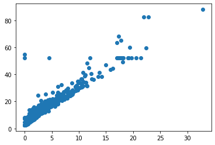

```python
plt.scatter(df.trip_distance,df.fare_amount)
```

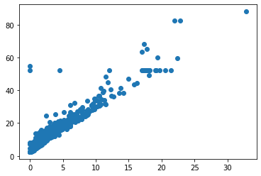

```python
plt.scatter(df.trip_distance,df.fare_amount);
```

# Matplotlib Axes

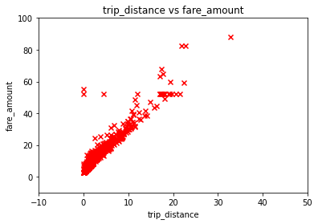

```python
fig,ax = plt.subplots(1,1,figsize=(6,4))

ax.scatter(x=df.trip_distance,
           y=df.fare_amount,
           marker='x',
           color='red'
          )

ax.set_xlabel('trip_distance')
ax.set_ylabel('fare_amount')

ax.set_xlim([-10,50])
ax.set_ylim([-10,100])

ax.set_title('trip_distance vs fare_amount');
```

# Matplotlib: Subplots, Figure and Axis

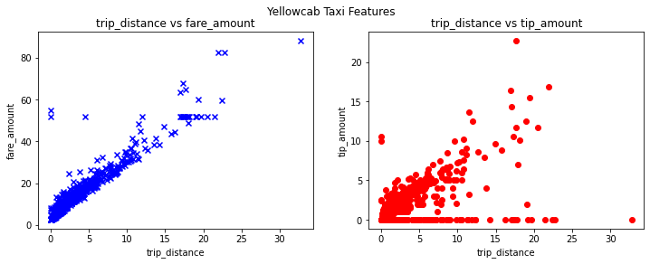

```python
fig,ax = plt.subplots(1,2,figsize=(12,4))

ax[0].scatter(df.trip_distance,df.fare_amount,marker='x',color='blue')
ax[1].scatter(df.trip_distance,df.tip_amount,color='red');

ax[0].set_xlabel('trip_distance')
ax[1].set_xlabel('trip_distance')

ax[0].set_ylabel('fare_amount'), ax[1].set_ylabel('tip_amount')

ax[0].set_title('trip_distance vs fare_amount')
ax[1].set_title('trip_distance vs tip_amount')

fig.suptitle('Yellowcab Taxi Features');
```

# Plotting via Pandas

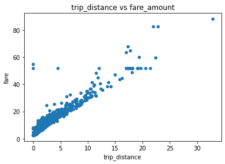

```python
ax = df.plot.scatter(x='trip_distance',y='fare_amount');
ax.set_ylabel('fare')
ax.set_title('trip_distance vs fare_amount');
```

# Univariate Distribution: Histogram

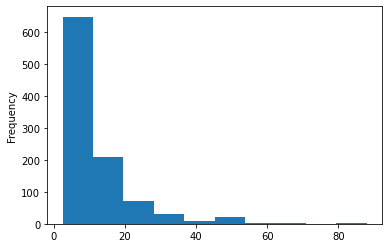

```python
df.fare_amount.plot.hist();
```

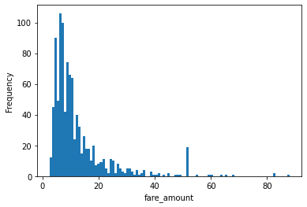

```python
ax = df.fare_amount.plot.hist(bins=100)
ax.set_xlabel('fare_amount');
```

# Univariate Distribution: Histogram

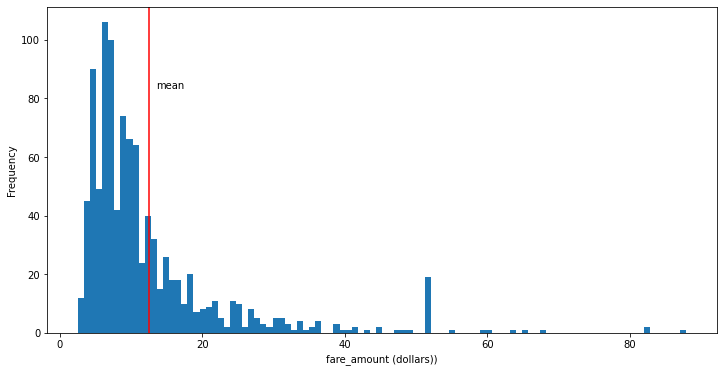

```python
fig,ax = plt.subplots(1,1,figsize=(12,6));

df.fare_amount.plot.hist(bins=100, ax=ax);
ax.set_xlabel('fare_amount (dollars))');

# add a vertical line
ax.axvline(df.fare_amount.mean(),color='r');
#ax.vlines(df.fare_amount.mean(),*ax.get_ylim(),color='r');

# add some text
ax.text(df.fare_amount.mean()+1,ax.get_ylim()[1]*.75,'mean');
```

# Subplots with Pandas

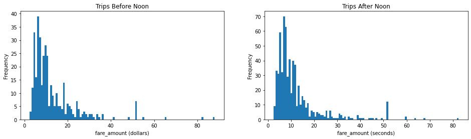

```python
fig,ax = plt.subplots(1,2,figsize=(16,4))
df[df.pickup_datetime.dt.hour < 12].fare_amount.plot.hist(bins=100,ax=ax[0]);
ax[0].set_xlabel('fare_amount (dollars)');
ax[0].set_title('Trips Before Noon');
df[df.pickup_datetime.dt.hour >= 12].fare_amount.plot.hist(bins=100,ax=ax[1]);
ax[1].set_xlabel('fare_amount (seconds)');
ax[1].set_title('Trips After Noon');
```

# Sharing Axes

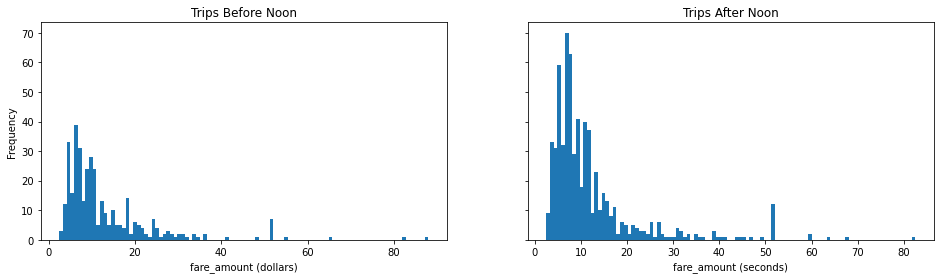

```python
fig,ax = plt.subplots(1,2,figsize=(16,4), sharey=True)

df[df.pickup_datetime.dt.hour < 12].fare_amount.plot.hist(bins=100,ax=ax[0]);
ax[0].set_xlabel('fare_amount (dollars)');
ax[0].set_title('Trips Before Noon');
df[df.pickup_datetime.dt.hour >= 12].fare_amount.plot.hist(bins=100,ax=ax[1]);
ax[1].set_xlabel('fare_amount (seconds)');
ax[1].set_title('Trips After Noon');
```

# Plotting with Seaborn

- Python data visualization library
- Based on matplotlib.
- It provides a high-level interface for drawing attractive and informative statistical graphics.

[figure not shown]

```python
import seaborn as sns
sns.__version__
```

```
'0.11.2'
```

# Univariate Distribution with Seaborn Histplot

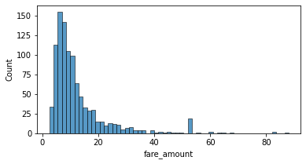

```python
fig,ax = plt.subplots(1,1,figsize=(6,3))

sns.histplot(x='fare_amount',data=df,ax=ax);
```

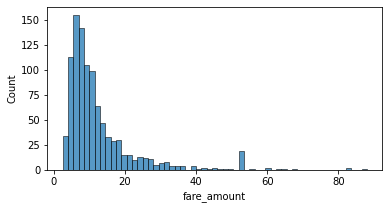

```python
fig,ax = plt.subplots(1,1,figsize=(6,3))

sns.histplot(x=df.fare_amount,ax=ax);
```

# Univariate Distribution with Seaborn Histplot Cont.

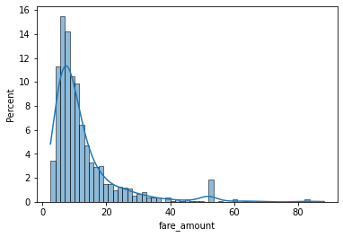

```python
fig,ax = plt.subplots(1,1,figsize=(6,4))

# many other parameters to play with
sns.histplot(x='fare_amount',data=df,ax=ax,kde=True,stat='percent');
```

# Aside: KDE

[figure not shown]

# Seaborn Styles

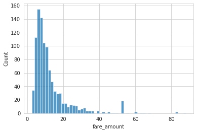

```python
# for a single plot using a context
with sns.axes_style('whitegrid'):
    sns.histplot(x=df.fare_amount);
```

```python
# set style globally
sns.set_style('darkgrid')
```

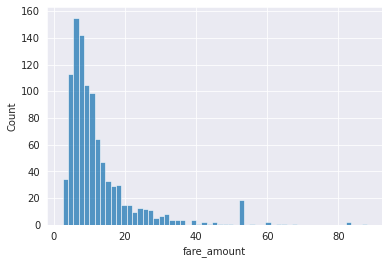

```python
sns.histplot(x=df.fare_amount);
```

# Univariate Distributions: Boxplot

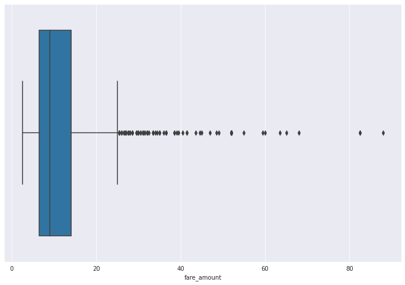

```python
fig,ax = plt.subplots(1,1,figsize=(12,8))

sns.boxplot(x=df.fare_amount,ax=ax);
```

# Univariate Distributions: Boxplot

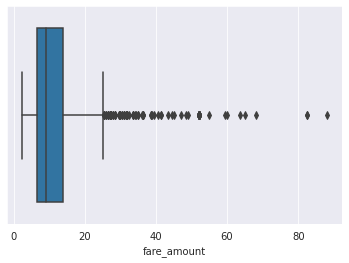

```python
fig,ax = plt.subplots(1,1,figsize=(6,4))

sns.boxplot(x=df.fare_amount,ax=ax);
```

- first quartile
- second quartile (Median)
- third quartile
- whiskers (usually 1.5*IQR)
- outliers

# Combining Plots with Subplots

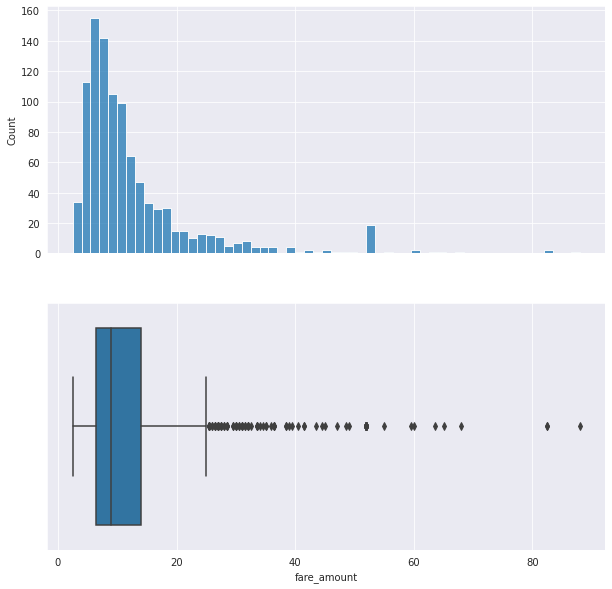

```python
fig,ax = plt.subplots(2,1,figsize=(10,10), sharex=True)

sns.histplot(x=df.fare_amount, ax=ax[0]);
sns.boxplot(x=df.fare_amount, ax=ax[1]);
```

# Other Univariate Distribution Visualizations

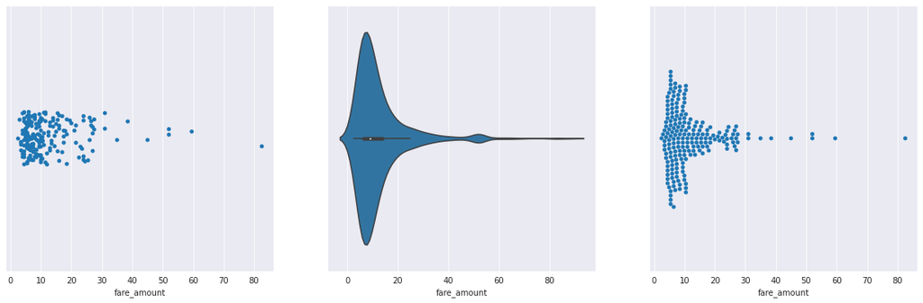

```python
fig,ax = plt.subplots(1,3,figsize=(20,6))

sns.stripplot(x='fare_amount',data=df[:200],ax=ax[0])
sns.violinplot(x='fare_amount',data=df,ax=ax[1])
sns.swarmplot(x='fare_amount',data=df[:200],ax=ax[2]);
```

# Bivariate: Evaluating Correlation

- **Correlation:** the degree to which two variables are linearly related
- Pearson Correlation Coefficient: $\rho_{XY} = \frac{cov(X,Y)}{\sigma_X\sigma_Y}$
- Sample Correlation: $r = \frac{\sum (x_i - \bar{x})(y_i - \bar{y})}{(n-1)s_xs_y}$
- Takes values between:
  - -1 (highly negatively correlated)
  - 0 (not correlated)
  - 1 (highly positively correlated)

```python
df.trip_distance.corr(df.fare_amount)
```

```
0.948701076897808
```

```python
from scipy.stats import pearsonr
r,p = pearsonr(df.trip_distance, df.fare_amount)
r,p
```

```
(0.9487010768978079, 0.0)
```

# Pearson Correlation

[figure not shown]

# Bivariate: Scatterplot

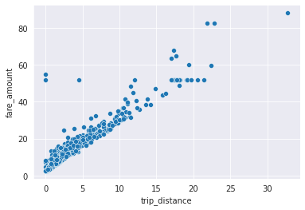

```python
sns.scatterplot(x='trip_distance',y='fare_amount',data=df);
```

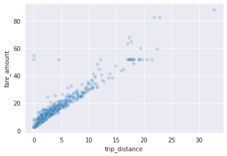

```python
sns.scatterplot(x='trip_distance',y='fare_amount',data=df,alpha=0.2);
```

# Bivariate: Add Regression Line

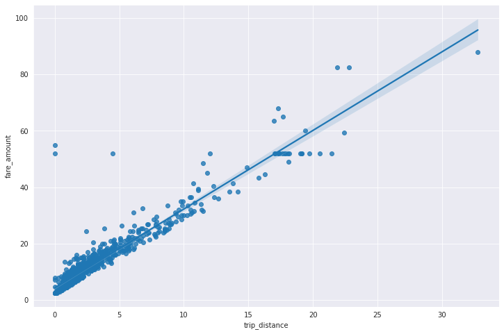

```python
fig,ax = plt.subplots(1,1,figsize=(12,8))

sns.regplot(x='trip_distance',y='fare_amount',data=df,ax=ax);
```

# Bivariate: Joint Plot

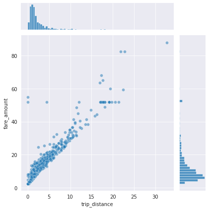

```python
sns.jointplot(x='trip_distance',y='fare_amount',data=df,alpha=0.5);
```

# Bivariate: Joint Plot with KDE

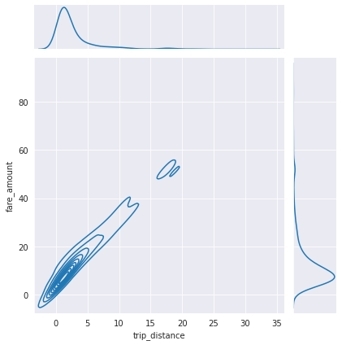

```python
sns.jointplot(x='trip_distance', y='fare_amount',
              data=df,
              kind='kde');
```

# Comparing Multiple Variables with `pairplot`

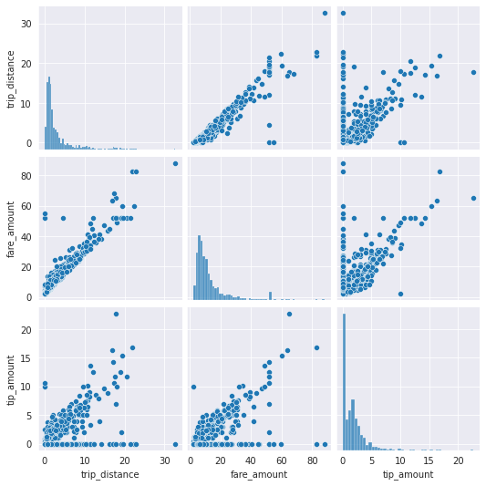

```python
sns.pairplot(df[['trip_distance','fare_amount','tip_amount']]);
```

# Categorical Variables: Frequency

```python
df.payment_type.value_counts()
```

```
Credit card    663
Cash           335
No charge        2
Name: payment_type, dtype: int64
```

```python
df.payment_type.value_counts(normalize=True)
```

```
Credit card    0.663
Cash           0.335
No charge      0.002
Name: payment_type, dtype: float64
```

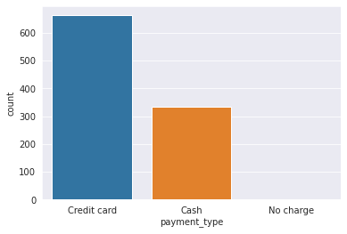

```python
sns.countplot(x=df.payment_type);
```

# Plotting Numeric and Categorical

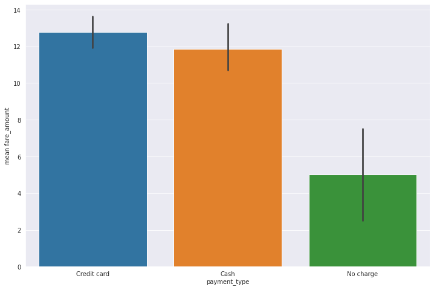

```python
fig,ax = plt.subplots(1,1,figsize=(12,8))

sns.barplot(x='payment_type',y='fare_amount',data=df,estimator=np.mean,ci=95);
ax.set_ylabel('mean fare_amount');
```

# Plotting with Hue

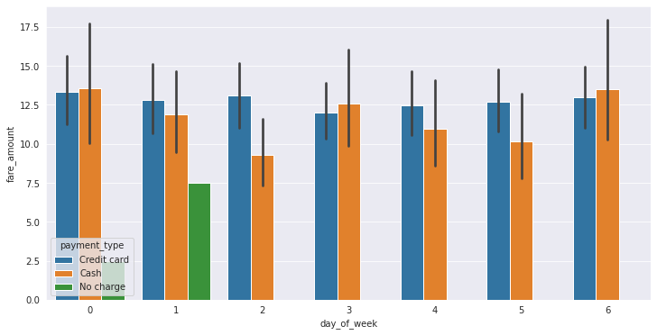

```python
fig,ax = plt.subplots(1,1,figsize=(12,6))

# add a second categorical variable day_of_week
sns.barplot(x='day_of_week',
            y='fare_amount',
            hue='payment_type',
            data=df);
```

# Same Axis, Multiple Plots with Seaborn

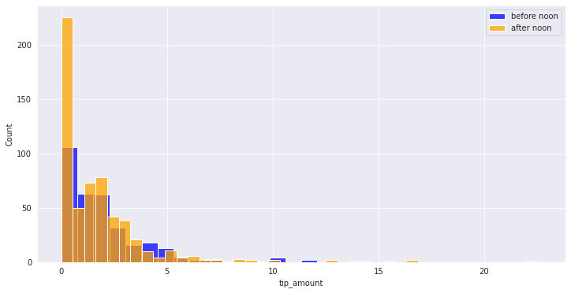

```python
fig,ax = plt.subplots(1,1,figsize=(12,6))
sns.histplot(x=df[df.pickup_datetime.dt.hour < 12].tip_amount, label='before noon',color='blue',ax=ax);
sns.histplot(x=df[df.pickup_datetime.dt.hour >= 12].tip_amount, label='after noon',color='orange',ax=ax);
plt.legend(loc='best');
```

# Data Exploration and Viz Review

- central tendencies: mean, median
- spread: variance, std deviation, IQR
- correlation: pearson correlation coefficient
- plotting real valued variables: histogram, scatter, regplot
- plotting categorical variables: count, bar
- plotting interactions: jointplot, pairplot